# Practical Machine Learning Course Project

Stepan Goncharov

22 March 2016

# Getting and cleaning data

At the first step we download and check the data and check what it consists of.

```r
library(caret)
library(rattle)
library(randomForest)
```

```r
library(rpart)

download.file("https://d396qusza40orc.cloudfront.net/predmachlearn/pml-training.csv", destfile = "pml-training.csv")
download.file("https://d396qusza40orc.cloudfront.net/predmachlearn/pml-testing.csv", destfile = "pml-testing.csv")

trainData <- read.csv("pml-training.csv")
testData <- read.csv("pml-testing.csv")
```

We see a lot of variables with near zero values. Then we have to remove variables with NA’s. First, we find number of NA’s in each variable and then clean our datasets.

```r
nzv <- nearZeroVar(trainData, saveMetrics = TRUE)
training <- trainData[,nzv$nzv == FALSE]

na <- apply(training, 2, function(x) sum(is.na(x)))

training <- training[names(training) %in% names(na[na == 0])]
testing <- testData[names(testData) %in% colnames(training)]
summary(training)
summary(testData)
```

[output not shown]

Then we remove variable “X” containing user numbers which is harmful for building machine learning models. We also should relevel “cvtd_timestamp” in both training ant testing sets.

```r
training <- training[,-1]
testing <- testing[,-1]
levels(testing$cvtd_timestamp) <- levels(training$cvtd_timestamp)
```

# Data partition

```r
inTrain <- createDataPartition(y = training$classe, p = .75, list = FALSE)
train_tr <- training[inTrain,]
train_te <- training[-inTrain,]
```

# LDA model

We ran LDA model first if we assume our data can be predicted be probabilistic approach. We got notifications about collinearity of our predictors. Lets group variables by PCA method to reduce number of correlated variables.

```r
lda.model <- train(classe ~ ., method = "lda", data = train_tr)
ldap.model <- train(train_tr$classe ~ ., method = "lda", preProcess = "pca", data = train_tr)

lda.predict <- predict(lda.model, train_te)
ldap.predict <- predict(ldap.model, train_te)
```

LDA with PCA is less accurate but we avoided collinear variables interrelation.

```r
confusionMatrix(lda.predict, train_te$classe)
```

```
## Confusion Matrix and Statistics
##
##           Reference
## Prediction    A    B    C    D    E
##          A 1286  109    3    0    0
##          B   88  718  124    2    0
##          C   21  116  705   82    5
##          D    0    6   23  674   90
##          E    0    0    0   46  806
##
## Overall Statistics
##
##                Accuracy : 0.8542
##                  95% CI : (0.844, 0.864)
##     No Information Rate : 0.2845
##     P-Value [Acc > NIR] : < 2.2e-16
##
##                   Kappa : 0.8156
##  Mcnemar's Test P-Value : NA
##
## Statistics by Class:
##
##                      Class: A Class: B Class: C Class: D Class: E
## Sensitivity            0.9219   0.7566   0.8246   0.8383   0.8946
## Specificity            0.9681   0.9459   0.9447   0.9710   0.9885
## Pos Pred Value         0.9199   0.7704   0.7589   0.8499   0.9460
## Neg Pred Value         0.9689   0.9418   0.9623   0.9684   0.9766
## Prevalence             0.2845   0.1935   0.1743   0.1639   0.1837
## Detection Rate         0.2622   0.1464   0.1438   0.1374   0.1644
## Detection Prevalence   0.2851   0.1900   0.1894   0.1617   0.1737
## Balanced Accuracy      0.9450   0.8512   0.8846   0.9046   0.9415
```

```r
confusionMatrix(ldap.predict, train_te$classe)
```

```
## Confusion Matrix and Statistics
##
##           Reference
## Prediction    A    B    C    D    E
##          A 1100  114   14    0    0
##          B  228  620  206   34    0
##          C   67  191  560  116    3
##          D    0   24   73  516  222
##          E    0    0    2  138  676
##
## Overall Statistics
##
##                Accuracy : 0.708
##                  95% CI : (0.695, 0.7207)
##     No Information Rate : 0.2845
##     P-Value [Acc > NIR] : < 2.2e-16
##
##                   Kappa : 0.6323
##  Mcnemar's Test P-Value : NA
##
## Statistics by Class:
##
##                      Class: A Class: B Class: C Class: D Class: E
## Sensitivity            0.7885   0.6533   0.6550   0.6418   0.7503
## Specificity            0.9635   0.8817   0.9069   0.9222   0.9650
## Pos Pred Value         0.8958   0.5699   0.5977   0.6180   0.8284
## Neg Pred Value         0.9197   0.9138   0.9256   0.9292   0.9450
## Prevalence             0.2845   0.1935   0.1743   0.1639   0.1837
## Detection Rate         0.2243   0.1264   0.1142   0.1052   0.1378
## Detection Prevalence   0.2504   0.2219   0.1911   0.1703   0.1664
## Balanced Accuracy      0.8760   0.7675   0.7809   0.7820   0.8577
```

Out-of sample errors is lowers for LDA without PCA than for LDA with PCA.

# Tree model

We can build tree model to classify the outcomes.

```r
tree.model <- train(classe ~ ., method = "rpart", data = train_tr)
print(tree.model$finalModel)
```

```
## n= 14718
##
## node), split, n, loss, yval, (yprob)
##       * denotes terminal node
##
##  1) root 14718 10533 A (0.28 0.19 0.17 0.16 0.18)
##    2) roll_belt< 130.5 13468  9295 A (0.31 0.21 0.19 0.18 0.11)
##      4) pitch_forearm< -34.35 1165     3 A (1 0.0026 0 0 0) *
##      5) pitch_forearm>=-34.35 12303  9292 A (0.24 0.23 0.21 0.2 0.12)
##       10) cvtd_timestamp02/12/2011 13:33>=0.5 981   256 A (0.74 0.26 0 0 0) *
##       11) cvtd_timestamp02/12/2011 13:33< 0.5 11322  8733 B (0.2 0.23 0.23 0.21 0.13)
##         22) magnet_dumbbell_z< -31.5 3813  2348 A (0.38 0.3 0.085 0.19 0.044)
##           44) raw_timestamp_part_1< 1.322838e+09 895    43 A (0.95 0.045 0.0034 0 0) *
##           45) raw_timestamp_part_1>=1.322838e+09 2918  1829 B (0.21 0.37 0.11 0.25 0.058) *
##         23) magnet_dumbbell_z>=-31.5 7509  5265 C (0.11 0.19 0.3 0.22 0.17) *
##    3) roll_belt>=130.5 1250    12 E (0.0096 0 0 0 0.99) *
```

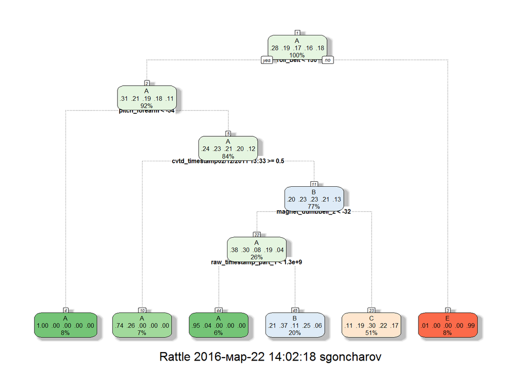

```r
fancyRpartPlot(tree.model$finalModel, cex = 0.5)
```

We see that A class detected quite well but others are not so distinct, Let’s see how correct tree model classify test set.

```r
tree.predict <- predict(tree.model, train_te, type = "raw")
confusionMatrix(tree.predict, train_te$classe)
```

```
## Confusion Matrix and Statistics
##
##           Reference
## Prediction   A   B   C   D   E
##          A 921  89   2   0   0
##          B 185 374 122 249  56
##          C 287 486 731 555 452
##          D   0   0   0   0   0
##          E   2   0   0   0 393
##
## Overall Statistics
##
##                Accuracy : 0.4933
##                  95% CI : (0.4792, 0.5074)
##     No Information Rate : 0.2845
##     P-Value [Acc > NIR] : < 2.2e-16
##
##                   Kappa : 0.3653
##  Mcnemar's Test P-Value : NA
##
## Statistics by Class:
##
##                      Class: A Class: B Class: C Class: D Class: E
## Sensitivity            0.6602  0.39410   0.8550   0.0000  0.43618
## Specificity            0.9741  0.84526   0.5604   1.0000  0.99950
## Pos Pred Value         0.9101  0.37931   0.2911      NaN  0.99494
## Neg Pred Value         0.8782  0.85324   0.9482   0.8361  0.88734
## Prevalence             0.2845  0.19352   0.1743   0.1639  0.18373
## Detection Rate         0.1878  0.07626   0.1491   0.0000  0.08014
## Detection Prevalence   0.2064  0.20106   0.5120   0.0000  0.08055
## Balanced Accuracy      0.8171  0.61968   0.7077   0.5000  0.71784
```

Accuracy is quite low which is not so good. Out-of-sample error is very large. We can try random forest to bag our predictors as one of the most accurate models.

# Random forest model

```r
rf.model <- randomForest(classe ~ ., data = train_tr)
rf.predict <- predict(rf.model, train_te)
confusionMatrix(rf.predict, train_te$classe)
```

```
## Confusion Matrix and Statistics
##
##           Reference
## Prediction    A    B    C    D    E
##          A 1395    1    0    0    0
##          B    0  948    1    0    0
##          C    0    0  854    0    0
##          D    0    0    0  804    0
##          E    0    0    0    0  901
##
## Overall Statistics
##
##                Accuracy : 0.9996
##                  95% CI : (0.9985, 1)
##     No Information Rate : 0.2845
##     P-Value [Acc > NIR] : < 2.2e-16
##
##                   Kappa : 0.9995
##  Mcnemar's Test P-Value : NA
##
## Statistics by Class:
##
##                      Class: A Class: B Class: C Class: D Class: E
## Sensitivity            1.0000   0.9989   0.9988   1.0000   1.0000
## Specificity            0.9997   0.9997   1.0000   1.0000   1.0000
## Pos Pred Value         0.9993   0.9989   1.0000   1.0000   1.0000
## Neg Pred Value         1.0000   0.9997   0.9998   1.0000   1.0000
## Prevalence             0.2845   0.1935   0.1743   0.1639   0.1837
## Detection Rate         0.2845   0.1933   0.1741   0.1639   0.1837
## Detection Prevalence   0.2847   0.1935   0.1741   0.1639   0.1837
## Balanced Accuracy      0.9999   0.9993   0.9994   1.0000   1.0000
```

Random forest seems to be very accurate method for resolving this type of task. We can check how many variables are enough to get good results.

```r
rf.cv <- rfcv(trainx = train_tr[,-58], trainy = train_tr[,58], cv.fold = 10)
rf.cv$error.cv
```

```
##           57           28           14            7            4
## 0.0011550482 0.0008153282 0.0006114961 0.0003397201 0.0038048648
##            1
## 0.4128957739
```

```r
head(sort(importance(rf.model)[,1], decreasing = TRUE), 7)
```

```
##       cvtd_timestamp raw_timestamp_part_1           num_window
##            1817.1850            1199.8095             726.2308
##            roll_belt             yaw_belt    magnet_dumbbell_y
##             615.7492             426.4821             420.1538
##    magnet_dumbbell_z
##             386.1322
```

```r
rf.model_7 <- randomForest(classe ~ cvtd_timestamp + raw_timestamp_part_1 + num_window + roll_belt + yaw_belt + pitch_forearm + magnet_dumbbell_y, data = train_tr)
rf.predict_7 <- predict(rf.model_7, train_te)
confusionMatrix(rf.predict_7, train_te$classe)
```

```
## Confusion Matrix and Statistics
##
##           Reference
## Prediction    A    B    C    D    E
##          A 1395    0    0    0    0
##          B    0  949    1    0    0
##          C    0    0  854    0    0
##          D    0    0    0  804    0
##          E    0    0    0    0  901
##
## Overall Statistics
##
##                Accuracy : 0.9998
##                  95% CI : (0.9989, 1)
##     No Information Rate : 0.2845
##     P-Value [Acc > NIR] : < 2.2e-16
##
##                   Kappa : 0.9997
##  Mcnemar's Test P-Value : NA
##
## Statistics by Class:
##
##                      Class: A Class: B Class: C Class: D Class: E
## Sensitivity            1.0000   1.0000   0.9988   1.0000   1.0000
## Specificity            1.0000   0.9997   1.0000   1.0000   1.0000
## Pos Pred Value         1.0000   0.9989   1.0000   1.0000   1.0000
## Neg Pred Value         1.0000   1.0000   0.9998   1.0000   1.0000
## Prevalence             0.2845   0.1935   0.1743   0.1639   0.1837
## Detection Rate         0.2845   0.1935   0.1741   0.1639   0.1837
## Detection Prevalence   0.2845   0.1937   0.1741   0.1639   0.1837
## Balanced Accuracy      1.0000   0.9999   0.9994   1.0000   1.0000
```

# Assigning predictions to the Testing dataset

The best results were obtained with random forest model so we can use it to assign the predictions to the testing file.

```r
final.test <- predict(rf.model, testing)
```